# Modelo GAM

Ana Karolina Silva

## 1 Introdução

- Os modelos “GAMs” permitem que cada variável explicativa tenha uma relação não linear e suave com a variável resposta, sem que precise escolher a forma exata da curva (como quadrática, cúbica, etc.).

O GAM é uma extensão dos modelos lineares generalizados (GLM), adicionando funções suaves aos termos explicativos.

- Para o relatório, Vou testar a influência do fósforo na razão entre a biomassa do zooplâncton pelo fitoplâncton que suspeito que não seja linear.
- Adicionei os dados da minha dissertação com um aquivo .csv no diretório `/Dados` da disciplina.

```r
#~~~~~~~~~~~~~~~~~~~~~~~~~~~~~~~~
# 1. Importando o banco de dados
#~~~~~~~~~~~~~~~~~~~~~~~~~~~~~~~~

dados <- read.table(file="../Dados/RELACAO_VAR_ABIOTICAS_RAZAO.csv", sep =";", header = T)
```

Visualizando informações contidas no banco de dados:

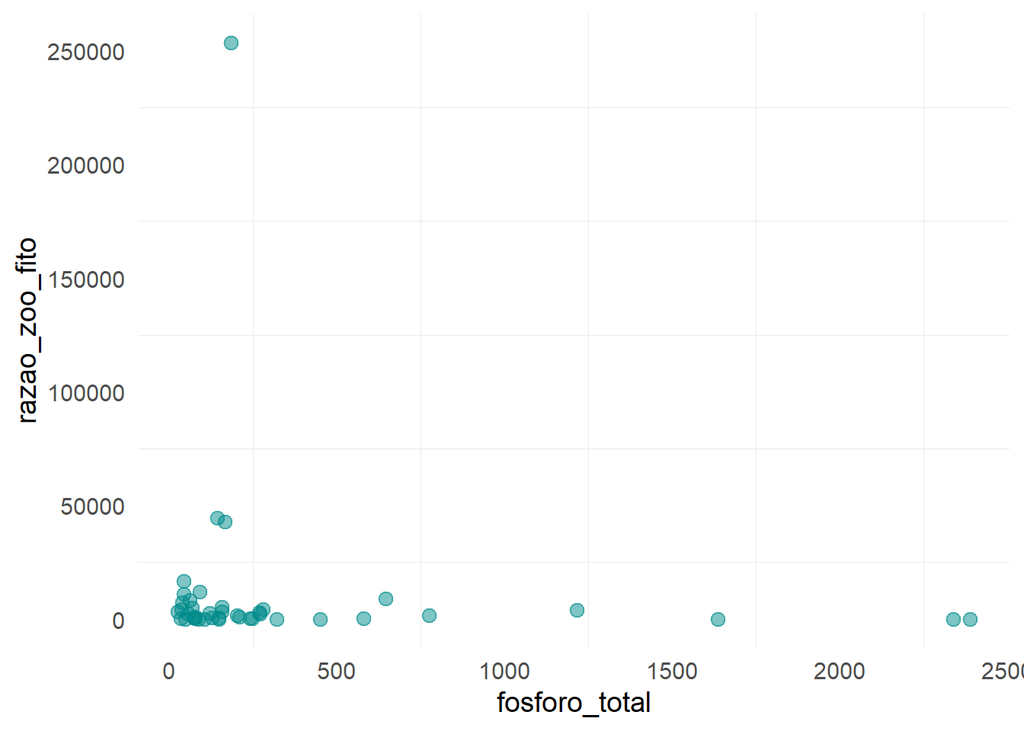

```r
## Explorando a relação razão zoo/fito vs.fósforo total
library(ggplot2)
ggplot(dados, aes(x = fosforo_total, y = razao_zoo_fito)) +
  geom_point(pch = 19, alpha =0.5, size = 3,
             col = 'cyan4') +
  #geom_smooth(method = "gam",col = 'darkorange', fill = '#b6ad90') +
  theme_minimal(base_size = 14) +
  #facet_wrap(Station ~ .) +
  theme(legend.position = "none",
        panel.grid.major = element_blank(),
        plot.title = element_text(hjust = 0.5, face = 'bold'))
```

- Não há uma tendência clara para a razão com relação ao fósforo total nem com o tempo.

- Há valores de menor razão em torno de valores menores de fósforo, mas há valores menores em torno de níveis altos de fósforo também.

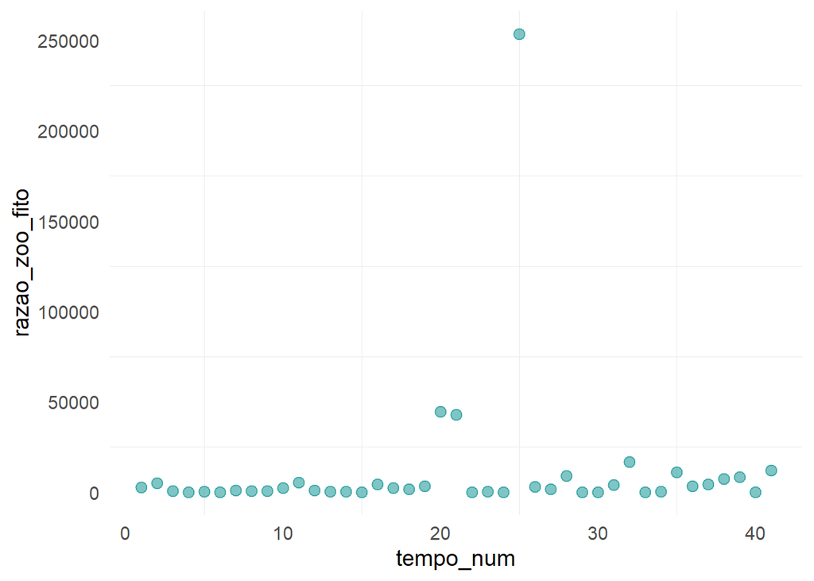

```r
## Explorando a relação razão zoo/fito vs.fósforo total
library(ggplot2)
ggplot(dados, aes(x = tempo_num, y = razao_zoo_fito)) +
  geom_point(pch = 19, alpha =0.5, size = 3,
             col = 'cyan4') +
  #geom_smooth(method = "gam",col = 'darkorange', fill = '#b6ad90') +
  theme_minimal(base_size = 14) +
  #facet_wrap(Station ~ .) +
  theme(legend.position = "none",
        panel.grid.major = element_blank(),
        plot.title = element_text(hjust = 0.5, face = 'bold'))
```

- No tempo não muita variação, exceto em 3 observações que o valor da razão foi bem alto.

## 2 Testando modelos

```r
## Modelo com relação puramente linear
library(DHARMa) #avaliação dos residuos
```

```r
library(performance) #avaliação dos residuos
library(ggeffects) #para plotar os resultados

m_glm <- glm(razao_zoo_fito ~ fosforo_total,
             data = dados,
             family = Gamma(link="log"))


## Modelo normal com termo quadrático
m_glm2 <- glm(razao_zoo_fito ~ poly(fosforo_total, 2),
              data = dados,
              family = gaussian)


## Modelo normal com termo cúbico
m_glm3 <- glm(razao_zoo_fito ~ poly(fosforo_total, 3),
              data = dados,
              family = gaussian)


## Modelo normal com termo à quarta
m_glm4 <- glm(razao_zoo_fito ~ poly(fosforo_total, 4),
              data = dados,
              family = gaussian)


AIC(m_glm, m_glm2, m_glm3, m_glm4)
```

```
##        df      AIC
## m_glm   3 764.1633
## m_glm2  4 991.9382
## m_glm3  5 993.7283
## m_glm4  6 995.1246
```

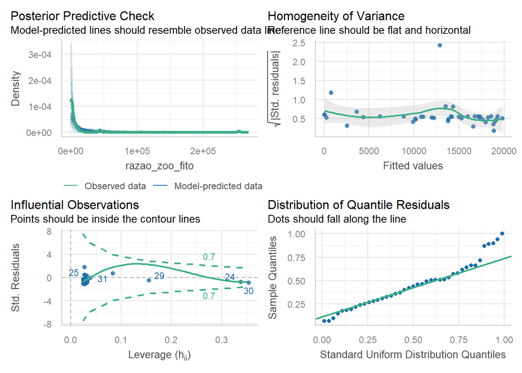

```r
## Análise dos pressupostos
simres1 <- simulateResiduals(m_glm, n=1000) #modelo mais simples
simres4 <- simulateResiduals(m_glm4, n=1000) #modelo mais complexo


check_model(simres1) #Modelo mais simples
```

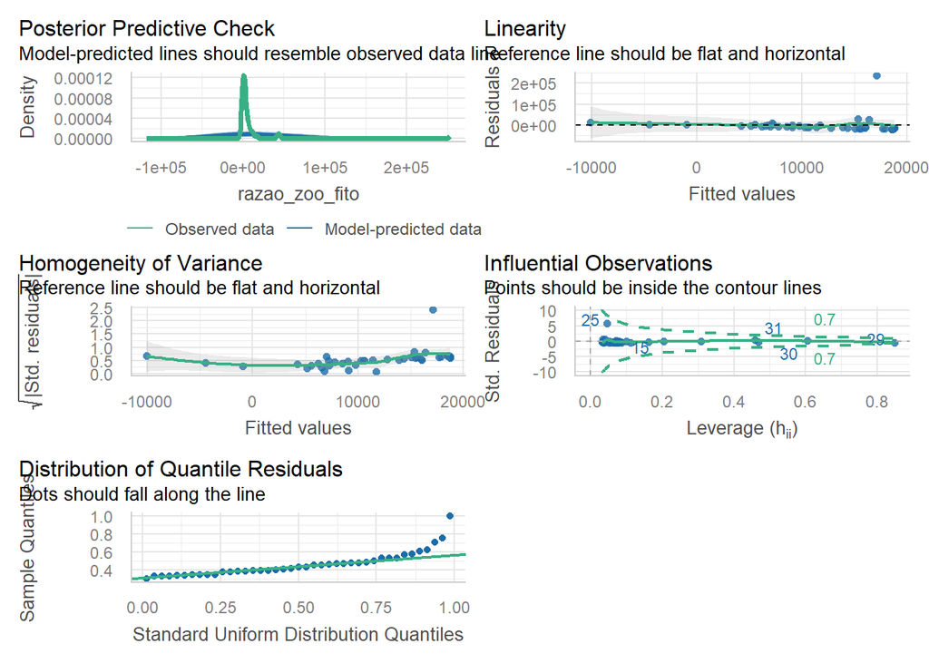

```r
check_model(simres4) #Modelo mais complexp
```

O modelo linear com familia Gamma apresentou menor AIC que os outros modelos mais complexos. Isso é um indicativo de que a relação entre a razão zoo/fito pode ser avaliada com ajustes num modelo glm mesmo, incluindo outras variáveis para explicar melhor os dados.

- observações:

No GLM há algus problemas com os valores preditos que não acompanham bem os dados observados e com a homogeneidade da variância.

*Mesmo assim vou testar um modelo GAM com esses dados para ver o resultado*.

## 3 Testando o modelo GAM

```r
### GAM com distribuição Gama
library(mgcv) #rodar gam
m_gam <- gam(razao_zoo_fito ~ s(fosforo_total, bs = "cr"),
              data = dados,
              family = Gamma(link = "log"))
summary(m_gam)
```

```
##
## Family: Gamma
## Link function: log
##
## Formula:
## razao_zoo_fito ~ s(fosforo_total, bs = "cr")
##
## Parametric coefficients:
##             Estimate Std. Error t value Pr(>|t|)
## (Intercept)    8.134      0.243   33.47   <2e-16 ***
## ---
## Signif. codes:  0 '***' 0.001 '**' 0.01 '*' 0.05 '.' 0.1 ' ' 1
##
## Approximate significance of smooth terms:
##                    edf Ref.df     F  p-value
## s(fosforo_total) 6.404  7.082 10.23 9.56e-07 ***
## ---
## Signif. codes:  0 '***' 0.001 '**' 0.01 '*' 0.05 '.' 0.1 ' ' 1
##
## R-sq.(adj) =  0.0591   Deviance explained = 46.7%
## GCV = 4.0058  Scale est. = 2.421     n = 41
```

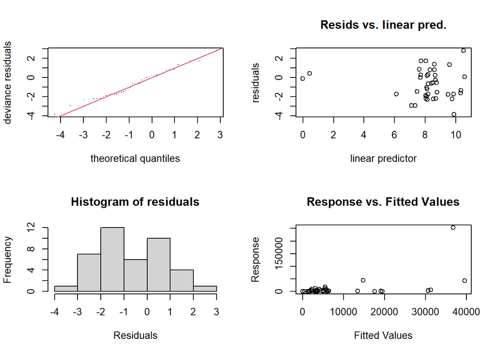

```
##
## Method: GCV   Optimizer: outer newton
## full convergence after 2 iterations.
## Gradient range [2.738857e-07,2.738857e-07]
## (score 4.005791 & scale 2.421048).
## Hessian positive definite, eigenvalue range [0.105516,0.105516].
## Model rank =  10 / 10
##
## Basis dimension (k) checking results. Low p-value (k-index<1) may
## indicate that k is too low, especially if edf is close to k'.
##
##                   k' edf k-index p-value
## s(fosforo_total) 9.0 6.4    0.78    0.46
```

```r
## Avaliando os pressupostos
par(mfrow = c(2,2))
gam.check(m_gam) #versão com pacote mgcv
```

```r
par(mfrow = c(1,1))

check_model(m_gam)
```

```
## Cannot simulate residuals for models of class `gam`. Please try
##   `check_model(..., residual_type = "normal")` instead.
```

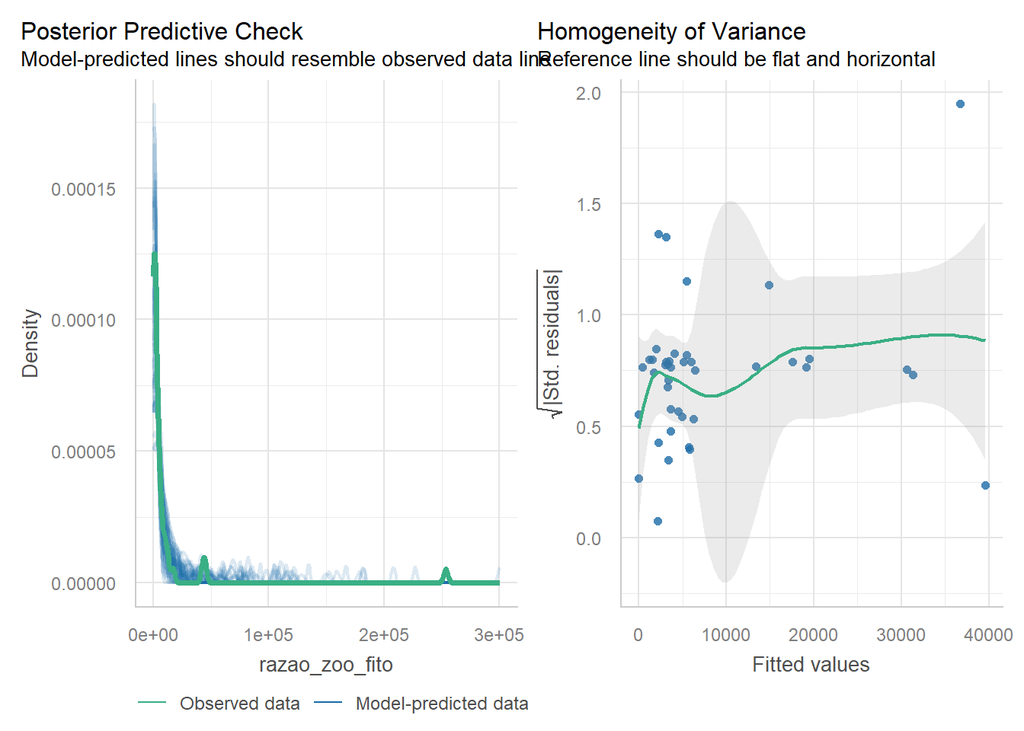

Observações:

- edf > 1 para o fósforo total, suavização significativa;
- A homogeneidade, por outro lado, piorou com relação ao modelo glm.

Além disso, há uma tendência de muitos resíduos em torno de valores altos do preditor linear.

```r
### Comparando AIC do GLM e do GAM

AIC(m_gam, m_glm)
```

```
##             df      AIC
## m_gam 8.403855 745.5257
## m_glm 3.000000 764.1633
```

- Observações: O modelo GAM possui menor AIC, no entanto o ajuste não parece melhor que o GLM.

## 4 Conclusão

Embora, a suavização do fósforo total tenha sido significativa, o modelo GAM com apenas essa variável não se mostrou melhor que o modelo GLM com a família Gamma para os dados da razão zoo/fito.

- Seguir com um modelo GLM mais simples incluindo mais variáveis ou até incluindo efeitos mistos pode ser melhor que usar com a modelagem GAM.
- Por outro lado, incluir mais variáveis no modelo GAM e trabalhar com fatores fixos e suavizados pode até melhorar o ajuste. São coisas que pretendo testar. O GAM precisa de um número considerável de observações talvez os meus dados não se enquadrem também.